# STATS 506 F20, Final Project

EunSeon Ahn, eunahn@umich.edu

December 14, 2020

## Introduction

Walking through the U of M campus, it's not difficult to observe the stark contrast between the architecture of Michigan's newer buildings like the Ross building (completed in 2009) lying across from the more traditional buildings making up Michigan's Law Quad (completed in 1933). This difference in style and structure of these two buildings demonstrates the underlying improvements/changes in labor, material, production, and new technology experienced by the construction industry. This project seeks to investigate how the construction materials used for wall and roof of buildings across US have changed throughout the years.

Additionally, the requirements of the building materials may be further specified by the size of the building. It is possible that while there may have been advancements in construction material or methods involving specific materials, it's only applicable to buildings of certain size. Consequently, in order to take the building size into consideration in looking at the usage of construction material through time, we'll consider the square footage of the building to address whether buildings of different sizes require (or have a preferential leaning towards) different building materials. To address these questions, we will consider point estimates and generate confidence intervals for these estimates using replicate weights provided in our data.

> How has the frequency of the types of wall and roof construction material changed throughout the years? Does the use of certain construction materials differ by the size of the building, as measured by square footage?

## Data

```r
# libraries: ------------------------------------------------------------------
library(tidyverse)

# Script: ---------------------------------------------------------------------

# Load data: ------------------------------------------------------------------
## CBEC Data
cbec = read_delim('./Data/2012_public_use_data_aug2016.csv',delim = ",") %>%
  select(id = PUBID, w = FINALWT, year = YRCONC, wall = WLCNS,
         roof = RFCNS, size = SQFTC)

## Replicate weights
weights =  read_delim('./Data/2012_public_use_data_aug2016.csv',
                      delim = ",") %>%
  select(id = PUBID, starts_with("FINALWT")) %>%
  select(-FINALWT)

### Convert replicate weights to long form

## Code taken from Dr. Henderson's lecture from 'Intro to Tidyverse'
long_weights = weights %>%
  pivot_longer(
    cols = starts_with('FINALWT'),
    names_to = 'rep',
    names_prefix = 'FINALWT',
    values_to = 'rw'
  ) %>%
  mutate(rep = as.integer(rep),
         id = as.integer(id))

## Codebook
codebook = readxl::read_excel('./Data/2012microdata_codebook.xlsx') %>%
  select(c(2,6,7))

variables = c(year = 'YRCONC', wall = 'WLCNS', roof = 'RFCNS', size = "SQFTC")

codes = codebook %>% filter( `Variable\r\nname` %in% variables) %>%
  transmute(
    variable = `Variable\r\nname`,
    temp =
      str_remove_all(`Values/Format codes`, pattern = "'")) %>%
  mutate(
    temp = str_split(temp, pattern = '\r\n')) %>%
  mutate(
    temp = lapply(temp, str_split_fixed, pattern = " = ", n = 2)) %>%
  mutate(
    levels = lapply(temp, function(m){m[,1]}),
    labels = lapply(temp, function(m){m[,2]})) %>%
  select(-temp)

codes$labels[[2]] = replace(codes$labels[[2]], c(3, 4, 6),
        c("Concrete block or poured concrete",
          "Aluminum, asbestos, plastic, or wood",
          "Window or vision glass"))

codes$labels[[3]] = replace(codes$labels[[3]], c(1, 3, 6),
                            c("Built-up (tar, felts, or fiberglass/ballast)",
                            "Wood shingles, shakes, or other wood",
                            "Plastic, rubber, or synthetic sheeting"))

## apply labels
decode_recs = function(x, varname, codes = codes){
  # Source: Dr. Henderson's Youtube lecture from 'Intro to Tidyverse'
  # apply factor labels to var using codebook "codes"
  # INPUTS:
  #   x - input vector to be changed to a factor
  #   varname - chr vector with name of the 'variable' in 'codes'
  #   codes - codebook of factor, levels, and labels
  # OUPTUT: x converted to a factor with levels givin in the codes

  with(filter(codes, variable == varname ),
       factor(x, levels = as.numeric(levels[[1]]), labels = labels[[1]]))
}

cbec = cbec %>%
  mutate(size = as.numeric(size),
         year = as.numeric(year)) %>%
  mutate(size = decode_recs(size,'SQFTC',codes),
         wall = decode_recs(wall,'WLCNS',codes),
         roof = decode_recs(roof,'RFCNS',codes),
         year = decode_recs(year,'YRCONC', codes),
         id = as.double(id))

## Collapse across size categories for wider size categories
cbec = cbec %>%
  mutate(size_group =
           fct_collapse(size,size1 = c("1,001 to 5,000 square feet" ,
                                       "5,001 to 10,000 square feet",
                                       "10,001 to 25,000 square feet"),
                        size2 = c("25,001 to 50,000 square feet",
                                  "50,001 to 100,000 square feet",
                                  "100,001 to 200,000 square feet"),
                        size3 = c("200,001 to 500,000 square feet",
                                  "500,001 to 1 million square feet",
                                  "Over 1 million square feet")))

cbec = cbec %>% mutate(size_group = recode(size_group,
                size1 = "1001 to 25,000 sq. ft.",
                size2 = "25,001 to 200,000 sq. ft.",
                size3 = "200,001 to over 1 mil. sq. ft"))
```

To address the above question, 2012 US Commercial Building Energy Consumption Survey ([CBECS](https://www.eia.gov/consumption/commercial/data/2012/index.php?view=microdata)) Data was analyzed. The variables `PUBID`, `YRCON`, `WLCONS`, `RFCNS`, `SQFTC`, and `FINALWT` were used for our analysis.

**Expand for detailed variable labels & values.**

| Variable | Label | Values / Format Codes |
| --- | --- | --- |
| `PUBID` | Building identifier | 00001 - 06720 |
| `YRCONC` | Year of construction category | 01 = Before 1920 02 = 1920 to 1945 03 = 1946 to 1959 04 = 1960 to 1969 05 = 1970 to 1979 06 = 1980 to 1989 07 = 1990 to 1999 08 = 2000 to 2003 09 = 2004 to 2007 10 = 2008 to 2012 |
| `WLCONS` | Wall construction material | 1 = Brick, stone, or stucco 2 = Pre-cast concrete panels 3 = Concrete block or poured concrete (above grade) 4 = Aluminum, asbestos, plastic, or wood materials (siding, shingles, tiles, or shakes) 5 =… |
| `RFCNS` | Roof construction material | 1 = Built-up (tar, felts, or fiberglass and a ballast, such as stone) 2 = Slate or tile shingles 3 = Wood shingles, shakes, or other wooden materials 4 = Asphalt, fiberglass, or other shingles 5 = Met… |
| `SQFTC` | Square footage category | 01 = 1,000 square feet or less 02 = 1,001 to 5,000 square feet 03 = 5,001 to 10,000 square feet 04 = 10,001 to 25,000 square feet 05 = 25,001 to 50,000 square feet 06 = 50,001 to 100,000 square feet 0… |
| `FINALWT` | Final full sample building weight | Numeric |
| `FINALWT..` | Final replicate weights | Numeric |

## Methods

```r
gen_CI = function(df, varA, varB){
  # Construct point estimates and confidence intervals

  # generate pt. estimates confidence intervals for var A grouped by var B
  #     by variable B
  # INPUTS:
  #   df - the tibble or data frame with all available values
  #   varA - variable of interest
  #   varB - variable you want to group varA by

  # OUPTUT: pt_CI - data frame containing variance, standard error, and lower and
  #         upper bounds of the 95% confidence interval

  pt_est = df %>% group_by_at(c(varA, varB)) %>%
    summarize(nTotal = sum(w)) %>%
    mutate(p = nTotal/sum(nTotal))

  pt_repl = df %>% select(-w) %>%
    left_join(long_weights, by = "id") %>%
    group_by_at(c(varA, "rep", varB)) %>%
    summarize(nTotal_repl = sum(rw)) %>%
    mutate(p_repl = nTotal_repl/sum(nTotal_repl)) %>% ungroup()

  # Calc. confidence intervals
  pt_var = pt_repl %>%
    select(-nTotal_repl) %>%
    left_join(pt_est, by = c(varA, varB)) %>%
    select(-nTotal) %>%
    group_by_at(c(varA, varB)) %>%
    summarize(p = mean(p), v =  sum({(p_repl - p)^2}))

  m = qnorm(.975)
  pt_CI = pt_var %>%
    mutate(
      se = sqrt(v),
      lwr = pmax(p - m * se, 0),
      upr = pmin(p + m * se, 1))

  return(pt_CI)
}

wall_year = gen_CI(cbec, "year", "wall") %>%
  mutate(across(all_of(c('p', 'lwr', 'upr')),
                 .fns = function(x) 100 * x))
wall_year_size = gen_CI(cbec, c("year", "size_group"), "wall") %>%
  mutate(across(all_of(c('p', 'lwr', 'upr')),
                .fns = function(x) 100 * x))

roof_year = gen_CI(cbec, "year", "roof") %>%
  mutate(across(all_of(c('p', 'lwr', 'upr')),
                .fns = function(x) 100 * x))
roof_year_size = gen_CI(cbec, c("year", "size_group"), "roof") %>%
  mutate(across(all_of(c('p', 'lwr', 'upr')),
                .fns = function(x) 100 * x))
```

To investigate the relationship between the construction materials and the construction year and whether certain materials are preferred for smaller vs. larger buildings, the proportion of buildings built with different wall and roof construction materials was calculated for each construction year and square footage category. The square footage categories provided by the CBEC dataset was further collapsed into 3 levels for a better chance finding meaningful distinction between the groups:

| Size Category 1 | 1001 to 25,000 square feet |
| --- | --- |
| Size Category 2 | 25,001 to 200,000 square feet |
| Size Category 3 | 200,001 to over 1 million square feet |

The 95% confidence intervals was calculated using the replicate weights through Jackknife method of estimating the standard error ([see for reference](https://www.eia.gov/consumption/commercial/data/2012/pdf/user_guide_public_use_aug2016.pdf)). The variance of a population parameter is estimated by:
$$\hat V( \hat \theta) = \sum\limits_{r=1}^R \alpha_r (\hat \theta_r - \hat \theta) ^2$$
where the coefficient for replicate r, $\alpha_r$, = 1 for the current dataset and the number of replicate samples. The code containing this analysis is available through this [github repository](https://github.com/EunseonAhn/FinalProject_506).

## Results

### Wall

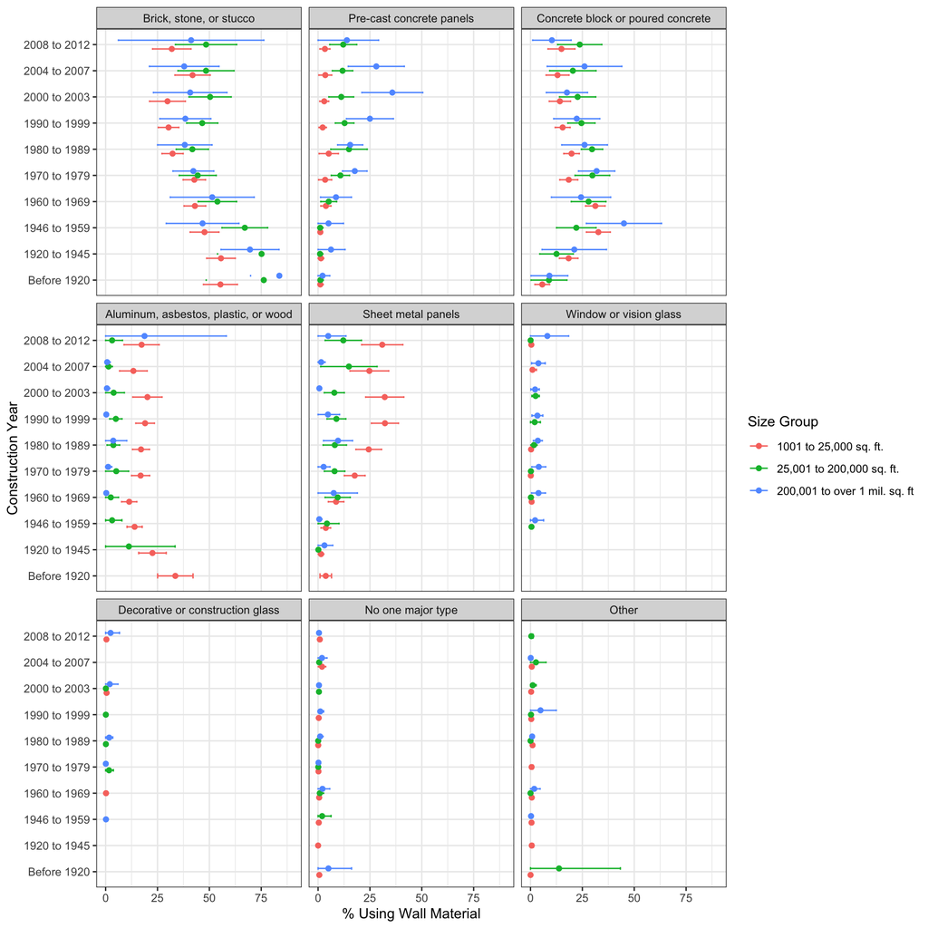

**Figure 1a.** *Percentage of Buildings with Wall Material By Year & Building Size*

```r
cap1a = paste(
 "**Figure 1a.** *Percentage of Buildings with Wall Material By Year & Building Size*"
)

## construct a plot
wall_year_size %>%
  mutate(`Size Group` = size_group) %>%
  ggplot( aes(x = year, y = p, color = `Size Group`) ) +
  geom_point( position = position_dodge(.5) ) +
  geom_point( position = position_dodge(.5) ) +
  geom_errorbar(
    aes(ymin = lwr, ymax = upr),
    position = position_dodge(.5), width = 0.2
  ) +
  facet_wrap(~ wall) +
  coord_flip() +
  theme_bw() +
  ylab('% Using Wall Material') +
  xlab('Construction Year') +
  ylim(c(0, 90))
```

#### **Usage of wall construction materials over time**

Regardless of the construction year, [brick, stone, or stucco] is the most popular material for walls with [concrete], [aluminum] and [sheet metal panels] walls also being widely used.

Over the years, sheet metal panels have gained more popularity, with this pattern being most obvious in smaller buildings (1001 - 25,000 sqft.). Similarly, aluminum walls are more widely used in smaller buildings categories. Alternatively, pre-cast concrete panel walls seem to be more preferentially used in large buildings category (200,001 - 1 mil. sqft.) with fairly limited use in the smaller buildings.

### Roof

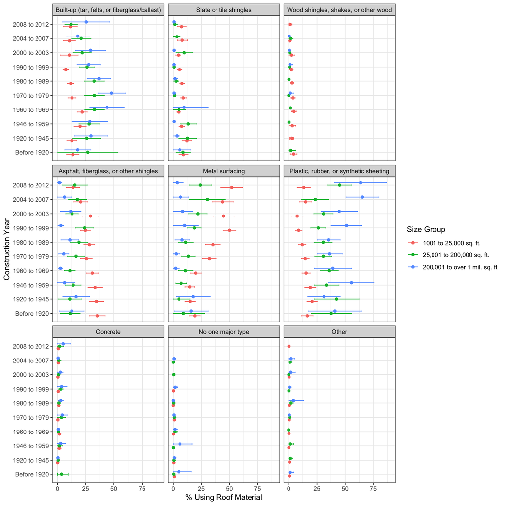

**Figure 2a.** *Percentage of Buildings with Roof Material By Year & Building Size*

```r
cap1b = paste(
 "**Figure 2a.** *Percentage of Buildings with Roof Material By Year & Building Size*"
)

## Plot for roof construction material by year/square footage
roof_year_size %>%
  mutate(`Size Group` = size_group) %>%
  ggplot( aes(x = year, y = p, color = `Size Group`)) +
  geom_point( position = position_dodge(.5) ) +
  geom_point( position = position_dodge(.5) ) +
  geom_errorbar(
    aes(ymin = lwr, ymax = upr),
    position = position_dodge(.5), width = 0.2
  ) +
  facet_wrap(~ roof) +
  coord_flip() +
  theme_bw() +
  ylab('% Using Roof Material') +
  xlab('Construction Year') +
  ylim(c(0, 90))
```

#### **Usage of roof construction materials over time**

From our analysis, [built-up (tar, felts, or fiberglass and a ballast)], [asphalt, fiberglass, or other shingles], [metal surfacing], and [rubber, or synthetic sheeting] are the more popular material for roof construction.

From the plots, the relationship between construction years and the roof construction material is most noticeable for metal surfacing roofs, with an overall increase in its use over the years. On the other hand, there is a stronger preference for different roof materials based on the size of the building. For example, [metal surfacing] or [asphalt, fiberglass, or other shingles] roofs are more widely used on smaller buildings (1001 - 25,000 sqft.), whereas [plastic, rubber, or synthetic sheeting] or [built-up (tar, felts, or fiberglass and a ballast)] roofs are more widely used for large buildings (200,000 - over 1 mil. sqft.). For these roof materials, the percentage of mid-sized buildings (25,001 - 200,000 sqft.) that use this materials falls somewhere in the middle of the two building sizes.

## Conclusion

From the analysis, we find that there is a change in frequency of different wall and roof materials used throughout the years. Furthermore, our data reveals a preferential use of different roof and wall materials for buildings based on their size.

One of the limitations of this analysis is that it does not take into consideration the number of floors of the building. Even though the square footage of the buildings were accounted for, skyscrapers are bound to have different construction and material constraints than a large single-floor building of the same square footage. Perhaps some sort of multiclass classification using logistics regression using all the variables like the construction year, square footage, number of floors, and other possible variables of interest may be better suited for studying what kind of buildings utilize specific building materials.

## Appendix

Included are the table of values which are plotted in the result section.

### Wall

```r
cap_tab1 = paste(
 "**Table 1.** *Wall construction material used by buildings (%) in 2012. *",
 "Numbers in parantheses represent 95% confidence intervals."
)

t = wall_year_size %>%
   mutate(
    pretty = sprintf('<div>%4.1f</div> <div>(%4.1f, %4.1f)</div>',
                     p, lwr, upr)
  )

pivot_all = function (t){
  # pivot data into wide format for every year category
  # INPUTS:
  #   t - table with years in long format
  # OUPTUT: t1 with each row containing point estimates for all categories of
  #   year

  t1 = list()

  for(i in 1: length(levels(t$year))) {

    t1[[i]] = t %>%
      filter(as.numeric(year) == i) %>%
      pivot_wider(
        id_cols = c('wall', 'size_group'),
        names_from = 'year',
        names_prefix = '',
        values_from = 'pretty',
        values_fill = '--'
      )
  }
  return (t1)
}

t1 = pivot_all(t)
joined = t1 %>%
  reduce(left_join, by = c("wall", "size_group"))

joined %>%
  rename(` ` = wall) %>%
  ungroup() %>%
  select(-size_group) %>%
  knitr::kable(
    format = 'html',
    escape = FALSE,
    align = 'llcccccc',
    cap = cap_tab1
  ) %>%
  kableExtra::kable_styling("striped", full_width = TRUE) %>%
  kableExtra::pack_rows("Size: 1001 to 25,000 sqft", 1, 7) %>%
  kableExtra::pack_rows("Size: 25,001 to 200,000 sqft", 8, 11) %>%
  kableExtra::pack_rows("Size: 200,001 to over 1 mil. sqft", 12, 15) %>%
  kableExtra::add_header_above(header = c('Wall Material' = 1, 'Construction Year' = 10))
```

**Table 1.** *Wall construction material used by buildings (%) in 2012.* Numbers in parantheses represent 95% confidence intervals.

| Wall Material | Construction Year Before 1920 | Construction Year 1920 to 1945 | Construction Year 1946 to 1959 | Construction Year 1960 to 1969 | Construction Year 1970 to 1979 | Construction Year 1980 to 1989 | Construction Year 1990 to 1999 | Construction Year 2000 to 2003 | Construction Year 2004 to 2007 | Construction Year 2008 to 2012 |
| --- | --- | --- | --- | --- | --- | --- | --- | --- | --- | --- |
| **Size: 1001 to 25,000 sqft** |  |  |  |  |  |  |  |  |  |  |
| Brick, stone, or stucco | 55.3 (47.2, 63.5) | 55.6 (48.7, 62.5) | 47.7 (40.7, 54.6) | 43.0 (37.8, 48.3) | 42.8 (37.3, 48.2) | 32.3 (27.2, 37.4) | 30.3 (25.4, 35.3) | 29.8 (21.2, 38.4) | 41.9 (33.4, 50.4) | 31.9 (22.6, 41.1) |
| Pre-cast concrete panels | 1.1 ( 0.0, 2.5) | 1.4 ( 0.0, 2.7) | 1.1 ( 0.0, 2.2) | 3.8 ( 1.3, 6.3) | 3.4 ( 0.3, 6.6) | 5.1 ( 0.5, 9.8) | 2.2 ( 0.4, 4.0) | 3.0 ( 0.8, 5.1) | 3.5 ( 0.4, 6.6) | 3.3 ( 0.9, 5.7) |
| Concrete block or poured concrete | 5.7 ( 2.1, 9.2) | 18.4 (13.9, 22.9) | 32.7 (27.0, 38.5) | 31.3 (26.5, 36.0) | 18.4 (14.1, 22.8) | 19.8 (16.0, 23.5) | 15.5 (11.9, 19.1) | 14.2 ( 9.0, 19.3) | 13.0 ( 7.5, 18.5) | 14.9 ( 8.4, 21.4) |
| Aluminum, asbestos, plastic, or wood | 33.6 (25.1, 42.1) | 22.6 (15.9, 29.2) | 14.0 (10.3, 17.6) | 11.4 ( 7.7, 15.0) | 16.9 (12.5, 21.2) | 17.0 (13.0, 21.1) | 19.0 (14.5, 23.5) | 20.1 (13.1, 27.2) | 13.4 ( 6.7, 20.0) | 17.3 ( 8.9, 25.8) |
| Sheet metal panels | 3.7 ( 0.9, 6.5) | 1.4 ( 0.1, 2.7) | 3.7 ( 1.4, 6.1) | 8.7 ( 4.9, 12.4) | 17.7 (12.7, 22.7) | 24.4 (18.2, 30.6) | 32.2 (25.7, 38.8) | 32.1 (22.9, 41.3) | 24.7 (15.4, 34.1) | 30.9 (21.0, 40.9) |
| No one major type | 0.6 ( 0.0, 1.4) | 0.0 ( 0.0, 0.1) | 0.3 ( 0.0, 1.1) | 0.5 ( 0.0, 1.2) | 0.2 ( 0.0, 0.6) | 0.1 ( 0.0, 0.2) | 0.3 ( 0.0, 0.8) | NA | 1.9 ( 0.1, 3.7) | 0.8 ( 0.0, 1.7) |
| Other | 0.0 ( 0.0, 0.1) | 0.6 ( 0.0, 1.3) | 0.5 ( 0.0, 1.3) | 0.6 ( 0.0, 1.6) | 0.5 ( 0.0, 1.2) | 1.0 ( 0.1, 1.9) | 0.4 ( 0.0, 1.0) | 0.3 ( 0.0, 0.8) | 0.6 ( 0.0, 1.6) | NA |
| **Size: 25,001 to 200,000 sqft** |  |  |  |  |  |  |  |  |  |  |
| Brick, stone, or stucco | 76.2 (48.5, 100.0) | 75.2 (53.9, 96.4) | 67.1 (56.1, 78.1) | 53.9 (44.6, 63.1) | 44.4 (35.5, 53.3) | 41.8 (34.0, 49.6) | 46.6 (39.1, 54.1) | 50.4 (40.2, 60.5) | 48.4 (34.9, 61.9) | 48.4 (33.6, 63.2) |
| Pre-cast concrete panels | 1.1 ( 0.0, 2.5) | 0.9 ( 0.0, 2.3) | 1.0 ( 0.0, 2.3) | 5.1 ( 1.3, 9.0) | 10.8 ( 6.4, 15.2) | 14.9 ( 6.1, 23.7) | 12.8 ( 8.3, 17.3) | 11.2 ( 5.2, 17.1) | 11.8 ( 6.9, 16.7) | 12.1 ( 5.6, 18.6) |
| Concrete block or poured concrete | 8.9 ( 0.3, 17.5) | 12.5 ( 4.5, 20.6) | 22.1 (12.6, 31.6) | 28.0 (19.7, 36.4) | 29.8 (21.5, 38.2) | 29.7 (24.5, 34.8) | 24.5 (18.0, 31.1) | 22.7 (14.0, 31.4) | 20.4 ( 9.2, 31.6) | 23.7 (13.1, 34.4) |
| Other | 13.8 ( 0.0, 43.3) | NA | NA | 0.0 ( 0.0, 0.0) | NA | 0.0 ( 0.0, 0.1) | 0.2 ( 0.0, 0.7) | 1.1 ( 0.0, 2.7) | 2.6 ( 0.0, 7.5) | 0.4 ( 0.0, 1.2) |
| **Size: 200,001 to over 1 mil. sqft** |  |  |  |  |  |  |  |  |  |  |
| Brick, stone, or stucco | 83.7 (69.9, 97.6) | 69.6 (55.6, 83.6) | 46.7 (29.2, 64.2) | 51.4 (31.1, 71.6) | 42.3 (32.4, 52.1) | 38.2 (25.0, 51.3) | 38.4 (26.1, 50.7) | 40.8 (23.0, 58.5) | 37.9 (21.1, 54.6) | 41.2 ( 6.1, 76.3) |
| Pre-cast concrete panels | 2.2 ( 0.0, 5.6) | 6.2 ( 0.0, 13.0) | 5.0 ( 0.0, 12.2) | 8.6 ( 1.2, 16.1) | 17.7 (11.8, 23.6) | 15.5 ( 9.4, 21.5) | 25.0 (13.7, 36.3) | 35.8 (21.1, 50.5) | 28.1 (14.5, 41.6) | 13.9 ( 0.0, 29.2) |
| Concrete block or poured concrete | 9.1 ( 0.3, 18.0) | 21.1 ( 5.6, 36.6) | 45.0 (26.9, 63.1) | 24.4 (10.1, 38.6) | 31.9 (23.1, 40.6) | 26.1 (15.1, 37.1) | 22.3 (11.2, 33.4) | 17.6 ( 7.6, 27.5) | 26.0 ( 8.0, 44.0) | 10.3 ( 1.0, 19.6) |
| No one major type | 5.0 ( 0.0, 16.1) | NA | NA | 2.1 ( 0.0, 5.6) | 0.2 ( 0.0, 0.6) | 1.0 ( 0.0, 2.4) | 1.1 ( 0.0, 2.7) | 0.4 ( 0.0, 1.0) | 1.9 ( 0.0, 4.3) | 0.4 ( 0.0, 1.5) |

### Roof

```r
cap_tab2 = paste(
 "**Table 2.** *Roof construction material used by buildings (%) in 2012. *",
 "Numbers in parantheses represent 95% confidence intervals."
)

t = roof_year_size %>%
   mutate(
    pretty = sprintf('<div>%4.1f</div> <div>(%4.1f, %4.1f)</div>',
                     p, lwr, upr)
  )

pivot_all = function (t){
  # pivot data into wide format for every year category
  # INPUTS:
  #   t - table with years in long format
  # OUPTUT: t1 with each row containing point estimates for all categories of
  #   year

  t1 = list()
  for(i in 1: length(levels(t$year))) {

    t1[[i]] = t %>%
      filter(as.numeric(year) == i) %>%
      pivot_wider(
        id_cols = c('roof', 'size_group'),
        names_from = 'year',
        names_prefix = '',
        values_from = 'pretty',
        values_fill = '--'
      )
  }
  return (t1)
}

t1 = pivot_all(t)
joined = t1 %>%
  reduce(left_join, by = c("roof", "size_group"))

joined %>%
  rename(` ` = roof) %>%
  ungroup() %>%
  select(-size_group) %>%
  knitr::kable(
    format = 'html',
    escape = FALSE,
    align = 'llcccccc',
    cap = cap_tab2
  ) %>%
  kableExtra::kable_styling("striped", full_width = TRUE) %>%
  kableExtra::pack_rows("Size: 1001 to 25,000 sqft", 1, 8) %>%
  kableExtra::pack_rows("Size: 25,001 to 200,000 sqft", 9, 16) %>%
  kableExtra::pack_rows("Size: 200,001 to over 1 mil. sqft", 17, 23) %>%
  kableExtra::add_header_above(header = c('Roof Material' = 1, 'Construction Year' = 10))
```

**Table 2.** *Roof construction material used by buildings (%) in 2012.* Numbers in parantheses represent 95% confidence intervals.

| Roof Material | Construction Year Before 1920 | Construction Year 1920 to 1945 | Construction Year 1946 to 1959 | Construction Year 1960 to 1969 | Construction Year 1970 to 1979 | Construction Year 1980 to 1989 | Construction Year 1990 to 1999 | Construction Year 2000 to 2003 | Construction Year 2004 to 2007 | Construction Year 2008 to 2012 |
| --- | --- | --- | --- | --- | --- | --- | --- | --- | --- | --- |
| **Size: 1001 to 25,000 sqft** |  |  |  |  |  |  |  |  |  |  |
| Built-up (tar, felts, or fiberglass/ballast) | 13.6 ( 8.0, 19.1) | 12.8 ( 8.3, 17.2) | 20.1 (14.8, 25.4) | 21.9 (17.6, 26.3) | 12.8 ( 9.2, 16.4) | 11.7 ( 8.8, 14.6) | 7.3 ( 4.9, 9.7) | 10.4 ( 2.5, 18.4) | 10.6 ( 5.2, 16.0) | 11.3 ( 5.0, 17.6) |
| Slate or tile shingles | 9.2 ( 5.0, 13.4) | 12.4 ( 8.2, 16.7) | 7.7 ( 5.1, 10.4) | 4.9 ( 3.2, 6.7) | 9.2 ( 6.3, 12.1) | 8.0 ( 5.8, 10.2) | 5.7 ( 3.4, 8.0) | 4.6 ( 2.2, 7.0) | 8.2 ( 3.5, 12.9) | 7.7 ( 3.7, 11.8) |
| Wood shingles, shakes, or other wood | 4.4 ( 1.5, 7.4) | 2.8 ( 1.1, 4.6) | 3.2 ( 0.2, 6.3) | 4.7 ( 2.7, 6.8) | 3.9 ( 2.0, 5.8) | 3.1 ( 1.5, 4.7) | 2.5 ( 1.0, 3.9) | 2.6 ( 0.0, 5.3) | 0.9 ( 0.0, 2.4) | 1.1 ( 0.0, 3.0) |
| Asphalt, fiberglass, or other shingles | 35.2 (28.5, 42.0) | 34.5 (28.4, 40.7) | 33.3 (27.1, 39.6) | 30.9 (25.5, 36.2) | 25.6 (20.5, 30.7) | 28.2 (23.5, 33.0) | 24.8 (20.4, 29.1) | 29.3 (22.2, 36.3) | 20.6 (14.6, 26.7) | 13.7 ( 7.6, 19.8) |
| Metal surfacing | 19.4 (14.8, 23.9) | 15.2 (10.7, 19.7) | 14.8 (10.7, 18.9) | 20.0 (15.2, 24.9) | 32.1 (25.9, 38.3) | 35.2 (28.5, 41.8) | 50.0 (44.5, 55.6) | 44.8 (35.5, 54.0) | 43.9 (34.5, 53.4) | 51.9 (42.4, 61.5) |
| Plastic, rubber, or synthetic sheeting | 16.5 (11.4, 21.5) | 20.7 (16.2, 25.2) | 19.1 (14.3, 24.0) | 15.4 (11.8, 19.0) | 14.6 (11.2, 18.1) | 12.0 ( 8.9, 15.2) | 8.9 ( 5.9, 11.8) | 7.5 ( 2.4, 12.7) | 15.0 ( 9.7, 20.4) | 13.4 ( 7.6, 19.1) |
| No one major type | 1.0 ( 0.1, 1.9) | 0.5 ( 0.0, 1.3) | NA | 0.2 ( 0.0, 0.6) | 1.0 ( 0.0, 2.0) | 0.0 ( 0.0, 0.0) | 0.2 ( 0.0, 0.6) | NA | NA | NA |
| Other | 0.8 ( 0.0, 1.6) | 0.8 ( 0.0, 1.7) | 0.1 ( 0.0, 0.4) | 0.3 ( 0.0, 0.8) | 0.5 ( 0.0, 1.0) | 0.6 ( 0.0, 1.4) | NA | 0.3 ( 0.0, 0.8) | NA | 0.3 ( 0.0, 0.8) |
| **Size: 25,001 to 200,000 sqft** |  |  |  |  |  |  |  |  |  |  |
| Built-up (tar, felts, or fiberglass/ballast) | 26.9 ( 0.2, 53.5) | 25.9 (13.7, 38.2) | 28.0 (19.2, 36.9) | 32.8 (24.3, 41.2) | 32.7 (24.1, 41.3) | 32.5 (23.7, 41.2) | 26.2 (19.7, 32.6) | 21.9 (14.0, 29.9) | 21.1 (12.5, 29.6) | 12.1 ( 6.5, 17.7) |
| Slate or tile shingles | 8.9 ( 2.5, 15.4) | 12.9 ( 4.9, 20.9) | 13.5 ( 6.4, 20.6) | 5.3 ( 0.0, 11.0) | 1.2 ( 0.0, 2.3) | 2.6 ( 0.5, 4.7) | 0.8 ( 0.0, 1.5) | 10.0 ( 2.5, 17.5) | 3.2 ( 0.1, 6.3) | 1.4 ( 0.0, 3.6) |
| Wood shingles, shakes, or other wood | 1.9 ( 0.0, 6.1) | NA | 0.3 ( 0.0, 0.9) | 1.6 ( 0.6, 2.6) | 0.1 ( 0.0, 0.3) | 0.3 ( 0.0, 0.6) | 0.8 ( 0.0, 1.6) | 0.9 ( 0.0, 2.0) | 1.8 ( 0.0, 3.9) | NA |
| Asphalt, fiberglass, or other shingles | 11.3 ( 2.4, 20.1) | 10.8 ( 0.5, 21.2) | 14.0 ( 7.0, 20.9) | 10.9 ( 6.0, 15.7) | 16.6 ( 8.8, 24.4) | 19.2 (11.5, 26.9) | 24.1 (16.1, 32.1) | 12.9 ( 7.3, 18.4) | 17.8 ( 9.7, 25.8) | 15.5 ( 4.6, 26.3) |
| Metal surfacing | 9.3 ( 0.0, 27.9) | 5.1 ( 0.0, 15.1) | 7.2 ( 2.3, 12.2) | 11.1 ( 4.5, 17.7) | 13.7 ( 7.8, 19.6) | 11.3 ( 4.7, 17.9) | 18.9 (13.1, 24.8) | 22.0 (14.0, 30.0) | 30.3 (14.3, 46.3) | 24.1 (14.4, 33.8) |
| Plastic, rubber, or synthetic sheeting | 37.7 (20.0, 55.4) | 42.4 (22.7, 62.2) | 33.7 (22.8, 44.6) | 36.0 (28.2, 43.9) | 30.6 (23.1, 38.1) | 30.5 (22.5, 38.5) | 26.1 (19.6, 32.7) | 30.8 (22.3, 39.3) | 23.5 (11.5, 35.6) | 45.1 (34.8, 55.4) |
| Concrete | 3.6 ( 0.0, 9.3) | 0.6 ( 0.0, 1.7) | 1.6 ( 0.0, 4.3) | 0.8 ( 0.0, 1.6) | 3.5 ( 0.0, 7.0) | 1.2 ( 0.0, 2.7) | 2.9 ( 0.9, 4.9) | 0.9 ( 0.0, 2.2) | 1.0 ( 0.0, 3.0) | 1.9 ( 0.0, 5.3) |
| No one major type | 0.5 ( 0.0, 1.1) | 0.6 ( 0.0, 1.9) | 0.2 ( 0.0, 0.4) | 1.6 ( 0.0, 3.7) | 0.9 ( 0.0, 2.3) | 0.5 ( 0.0, 1.2) | NA | 0.4 ( 0.0, 1.4) | 0.1 ( 0.0, 0.3) | NA |
| **Size: 200,001 to over 1 mil. sqft** |  |  |  |  |  |  |  |  |  |  |
| Built-up (tar, felts, or fiberglass/ballast) | 18.0 ( 6.4, 29.6) | 29.7 (15.2, 44.1) | 28.7 (12.7, 44.6) | 43.9 (28.7, 59.1) | 48.0 (35.9, 60.1) | 36.7 (26.3, 47.1) | 27.7 (17.5, 37.8) | 29.3 (16.1, 42.6) | 18.1 ( 8.3, 28.0) | 25.5 ( 4.6, 46.4) |
| Slate or tile shingles | 5.9 ( 0.0, 15.8) | 3.3 ( 0.5, 6.2) | 0.8 ( 0.0, 1.7) | 9.9 ( 0.0, 31.0) | 0.7 ( 0.0, 2.0) | 1.6 ( 0.0, 3.7) | 0.6 ( 0.0, 1.9) | 0.8 ( 0.0, 2.2) | NA | 0.7 ( 0.0, 1.8) |
| Asphalt, fiberglass, or other shingles | 12.7 ( 1.8, 23.6) | 16.6 ( 4.7, 28.5) | 6.2 ( 0.0, 15.5) | 2.6 ( 0.7, 4.5) | 5.5 ( 1.1, 9.9) | 10.9 ( 3.1, 18.8) | 2.9 ( 0.4, 5.5) | 11.6 ( 2.3, 20.9) | 6.2 ( 0.2, 12.2) | 1.6 ( 0.0, 3.8) |
| Metal surfacing | 16.1 ( 1.1, 31.0) | 17.8 ( 2.9, 32.8) | NA | 2.2 ( 0.0, 5.2) | 2.6 ( 0.0, 5.7) | 8.1 ( 1.5, 14.6) | 10.4 ( 0.0, 22.3) | 8.6 ( 0.0, 17.5) | 6.6 ( 0.0, 13.9) | 3.5 ( 0.0, 9.1) |
| Plastic, rubber, or synthetic sheeting | 41.0 (17.6, 64.5) | 31.3 (16.9, 45.6) | 55.5 (35.5, 75.6) | 39.2 (22.8, 55.6) | 36.3 (25.1, 47.5) | 35.5 (25.4, 45.6) | 51.2 (37.6, 64.8) | 44.7 (28.7, 60.8) | 65.3 (50.8, 79.9) | 63.7 (40.8, 86.6) |
| No one major type | 5.0 ( 0.0, 16.1) | 1.0 ( 0.0, 2.4) | 6.1 ( 0.0, 16.9) | 1.5 ( 0.0, 3.5) | 0.7 ( 0.0, 1.8) | 0.1 ( 0.0, 0.2) | 1.7 ( 0.0, 3.7) | NA | 0.7 ( 0.0, 2.0) | NA |
| Other | 1.4 ( 0.0, 4.4) | NA | NA | NA | 0.5 ( 0.0, 1.6) | 4.3 ( 0.0, 13.4) | 0.7 ( 0.0, 2.2) | 2.0 ( 0.0, 5.9) | 2.1 ( 0.0, 5.6) | NA |